# PELATIHAN KOMPUTASI 2023

# 5.6 Tuples dan Dictionaries

List datanya bisa diubah selama eksekusi program, sifatnya bernama mutable Sebaliknya tuple tidak bisa, sifatnya dinamakan immutable. Persamaannya keduanya sama-sama bisa menyimpan banyak nilai sekaligus dalam satu tipe data (sequence type)

## Tuples

Tuples are ordered and unchangeable (immutable) collections of data. They can be thought of as immutable lists. They are written in round brackets:

```python
myTuple = (1, 2, True, "a string", (3, 4), [5, 6], None)
print(myTuple)

myList = [1, 2, True, "a string", (3, 4), [5, 6], None]
print(myList)
```

```python
tuple1 = (1, 2, 4, 8)
tuple2 = 1., .5, .25, .125

print(tuple1)
print(tuple2)
```

```python
emptyTuple = ()
print(type(emptyTuple))
```

```python
myTuple = (1, 10, 100, 1000)

print(myTuple[0])
print(myTuple[-1])
print(myTuple[1:])
print(myTuple[:-2])

for elem in myTuple:
    print(elem)
```

```python
myTuple = (1, 10, 100, 1000)

myTuple.append(10000)
del myTuple[0]
myTuple[1] = -10
```

```python
myTuple = (1, 10, 100)

t1 = myTuple + (1000, 10000)
t2 = myTuple * 3

print(len(t2))
print(t1)
print(t2)
print(10 in myTuple)
print(-10 not in myTuple)
```

```python
# Example 1
t1 = (1, 2, 3)
for elem in t1:
    print(elem)

# Example 2
t2 = (1, 2, 3, 4)
print(5 in t2)
print(5 not in t2)

# Example 3
t3 = (1, 2, 3, 5)
print(len(t3))

# Example 4
t4 = t1 + t2
t5 = t3 * 2

print(t4)
print(t5)
```

## Dictionaries

In Python's world, the word you look for is named a key. The word you get from the dictionary is called a value.

Dictionaries are unordered*, changeable (mutable), and indexed collections of data. (*In Python 3.6x dictionaries have become ordered by default.

This means that a dictionary is a set of key-value pairs. Note:

- each key must be unique - it's not possible to have more than one key of the same value;
- a key may be data of any type: it may be a number (integer or float), or even a string;
- a dictionary is not a list - a list contains a set of numbered values, while a dictionary holds pairs of values;
- the len() function works for dictionaries, too - it returns the numbers of key-value elements in the dictionary;
- a dictionary is a one-way tool - if you have an English-French dictionary, you can look for French equivalents of English terms, but not vice versa.

```python
dict = {"cat" : "chat", "dog" : "chien", "horse" : "cheval"}
phoneNumbers = {'boss' : 5551234567, 'Suzy' : 22657854310}
emptyDictionary = {}

print(dict)
print(phoneNumbers)
print(emptyDictionary)
```

```python
print(dict['cat'])
print(phoneNumbers['Suzy'])
```

```python
dict = {"cat" : "chat", "dog" : "chien", "horse" : "cheval"}
words = ['cat', 'lion', 'horse']

for word in words:
    if word in dict:
        print(word, "->", dict[word])
    else:
        print(word, "is not in dictionary")
```

```python
dict = {"cat" : "chat", "dog" : "chien", "horse" : "cheval"}

for key in dict.keys():
    print(key, "->", dict[key])
```

```python
for key in sorted(dict.keys()):
    print(key, "->", dict[key])
```

## Items and Values

```python
dict = {"cat" : "chat", "dog" : "chien", "horse" : "cheval"}

for english, french in dict.items():
    print(english, "->", french)
```

```python
dict = {"cat" : "chat", "dog" : "chien", "horse" : "cheval"}

for french in dict.values():
    print(french)
```

## Replace

```python
dict = {"cat" : "chat", "dog" : "chien", "horse" : "cheval"}

dict['cat'] = 'minou'
print(dict)
```

## Adding new key

```python
dict = {"cat" : "chat", "dog" : "chien", "horse" : "cheval"}

dict['swan'] = 'cygne'
print(dict)
```

```python
#Latihan

#What happens when you attempt to run the following snippet?

myTup = (1, 2, 3)
print(myTup[2])
```

```python
#Latihan

#What is the output of the following snippet?

tup = 1, 2, 3
a, b, c = tup

print(a * b * c)
```

```python
#Latihan

#Complete the code to correctly use the count() method to find the number of duplicates of 2 in the following tuple.

tup = 1, 2, 3, 2, 4, 5, 6, 2, 7, 2, 8, 9
duplicates = # your code

print(duplicates)    # outputs: 4
```

```python
#Latihan

#Write a program that will "glue" the two dictionaries (d1 and d2) together and create a new one (d3).

d1 = {'Adam Smith':'A', 'Judy Paxton':'B+'}
d2 = {'Mary Louis':'A', 'Patrick White':'C'}
d3 = {}

for item in (d1, d2):
    # your code

print(d3)
```

```python
#Latihan

#Write a program that will convert the l list to a tuple.

l = ["car", "Ford", "flower", "Tulip"]

t = # your code
print(t)
```

```python
#Latihan

#Write a program that will convert the colors tuple to a dictionary.

colors = (("green", "#008000"), ("blue", "#0000FF"))

# your code

print(colDict)
```

```python
#Latihan

#What will happen when you run the following code?

myDict = {"A":1, "B":2}
copyMyDict = myDict.copy()
myDict.clear()

print(copyMyDict)
```

```python
#Latihan

#What is the output of the following program?

colors = {
    "white" : (255, 255, 255),
    "grey"  : (128, 128, 128),
    "red"   : (255, 0, 0),
    "green" : (0, 128, 0)
    }

for col, rgb in colors.items():
    print(col, ":", rgb)
```

# 6 Modules, Packages dan PIP

# Module

Kode memiliki kecenderungan untuk berkembang

Perkembangan kode sendiri, menjadi masalah yang terus berkembang

Ketika kode semakin banyak, kebutuhan untuk maintenance semakin rumit. Ketika kode itu sederhana, mencari masalah atau bug didalamnya jauh lebih mudah

Jika proyek ingin bisa selesai dengan baik, kita perlu 2 hal yaitu:

- bagi tugas ke sesama developers;
- kumpulkan semua bagian menjadi satu.

Contoh, suatu proyek bisa dibagi jadi 2 bagian:

- User Interface (bagian yang berkomunikasi dengan user melalui widget atau tampilan grafik)
- Logic (bagian yang memproses data dan membuahkan hasil)

Tiap bagian ini (kemungkinan besar) bisa dibagi menjadi bagian yang lebih kecil lagi, dan makin kecil lagi. Proses ini biasa disebut **decomposition**.

## Bagaimana caranya menggunakan module?

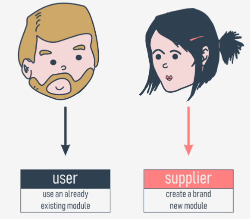

- pengguna (**user**) : Menggunakan module yang sudah ada
- penyedia (**supplier**) : Membuat module baru

a module dapat diidentifikasi dari **name**

Tiap module terdiri dari entitis (layaknya buku yang terdiri dari bab-bab). Dan entities ini bisa berupa functions, variables, constants, classes, dan objects.

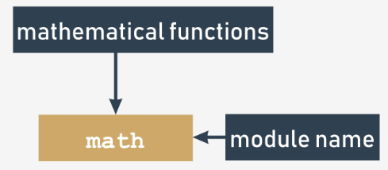

## Mengimport module

Mengimport module dilakukan dengan instruksi bernama `import`

Yang terdiri dari:

- keyword `import`
- `name` dari module itu tersebut

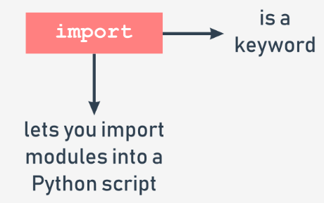

```python
import math
```

```python
import math, sys
```

## namespace

namespace adalah space/ruang (tidak secara harafiah) dimana `names` berada danm tidak saling bermasalah dengan `names` dari module lain (misal, tidak ada dua obyek berbeda dengan nama yang sama)

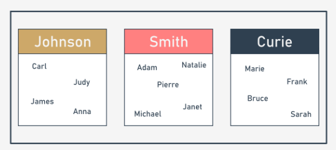

```python
import numpy
import math
import scipy

print(math.pi)
print(math.e)
print(numpy.pi)
print(scipy.pi)
#note: nilai pi dari module tidak berpengaruh dengan nilai pi yang kita definisikan sendiri
```

```python
from math import pi,e

print(pi)
print(e)
```

Instruksi ini terdiri dari beberapa elemen :

- `from` keyword;
- **name** dari modul yang akan diimport
- `import` keyword;
- **list of names** dari entity yang akan diimport ke namespace

```python
## override nilai sin dan pi
from math import sin, pi

print(sin(pi/2))

pi = 3.14

def sin(x):
    if 2 * x == pi:
        return 0.99999999
    else:
        return None

print(sin(pi/2))
```

## Mengimport semua modul

```python
from math import *

print(tan(0))
```

Nama dari entitas digantikan dengan asterisk tunggal `*`

`*` merupakan instruksi untuk meng-import semua entitas yang ada

## Aliasing

Untuk nama file yang akan di `import` kan dapat dilakukan proses `aliasing`

`Aliasing` menyebabkan `modul` diidentifikasi dengan `nama yang berbeda` dari `aslinya`

`import` module `as` alias

`as` merupakan kata kunci untuk melakukan `aliasing`

Jika kita ingin merename `math`, dengan `m` dapat dilakukan dengan cara sebagai berikut.

```python
import math as m

print(m.pi)
```

**Note** : Setelah berhasil melakukan aliasing, nama dari module aslinya akan menjadi tidak dapat diakses dan jangan digunakan

**from** `module` **import** `name` **as** `alias`

**from** `module` **import** `n` **as** `a`, `m` **as** `b`, `o` **as** `c`

```python
from math import pi as PI, sin as sine

print(sine(PI/2))
```

## Working with standard modules

**dir**(`module`)

Fungsi ini digunakan untuk memunculkan semua entity di dalam module yang ditulis. List ditampilkan urut abjad

```python
import math

dir(math)
```

```python
import math

a = math.pow(2,3)
print(a)

for name in dir(math):
    print(name, end="\t")
```

## module `math`

Berikut ini beberapa fungsi yang ada di module `math`

Fungsi trigonometri :

- `sin(x)` → nilai sinus dari x;
- `cos(x)` → nilai cosinus dari x;
- `tan(x)` → nilai tangen dari x.

Here are also their inversed versions:

- `asin(x)` → nilai arcsinus dari x;
- `acos(x)` → nilai arccosius dari x;
- `atan(x)` → nilai arctangen dari x.

`x` dalam bentuk radian

Fungsi ini mengambil satu argument dan me-return perhitungan nilai sudutnya dalam radian.

Selain itu, untuk menghitung sudut dengan lebih tepat lagi, kita bisa menggunakan beberapa fungsi ini:

- `pi` → konstanta dari aproksimasi dari nilai π;
- `radians(x)` → mengubah nilai x dari degree menjadi radian
- `degrees(x)` → sebaliknya (dari radian menjadi degree)

```python
from math import pi, radians, degrees, sin, cos, tan, asin

ad = 90

ar = radians(ad)
print(ar)
ad = degrees(ar)
print(ad)

print(ad == 90.)
print(ar == pi / 2.)
print(sin(ar) / cos(ar) == tan(ar))
print(asin(sin(ar)) == ar)
```

Another group of the math's functions is formed by functions which are connected with exponentiation:

- `e` → konstanta dari aproksimasi nilai bilangan natural Euler (e)
- `exp(x)` → nilai dari e pangkat x
- `log(x)` → logaritma natural dari x
- `log(x, b)` → logaritma dari x basis b
- `log10(x)` → logaritma dari x basis 10 (lebih presisi dibandingkan log(x,10))
- `log2(x)` → logaritma dari x basis 2 (lebih presisi dibandingkan log(x,2))

```python
from math import e, exp, log

print(pow(e, 1) == exp(log(e)))
print(pow(2, 2) == exp(2 * log(2)))
print(log(e, e) == exp(0))
```

#### Built-in function

Note: Fungsi pow()

`pow(x, y)` → nilai dari x pangkat y

fungsi ini sudah terdapat di python (built-in) tanpa perlu mengimport module lain

The last group consists of some general-purpose functions like:

- `ceil(x)` → ceiling dari x (pembulatan ke atas dari nilai x ke bilangan bulat terdekat)
- `floor(x)` → flooring dari x (pembulatan ke bawah dari nilai x ke bilangan bulat terdekat)
- `trunc(x)` → pembulatan nilai x
- `factorial(x)` → nilai dari x! (x harus positif)
- `hypot(x, y)` → mengembalikan nilai sisi miring (hipotenus) dari segitiga siku-siku dengan x dan y sebagai alas dan tinggi . (nilainya sama dengan `sqrt(pow(x, 2) + pow(y, 2))` tetapi lebih presisi). Biasa kita sebut teorema pythagoras

It demonstrates the fundamental differences between `ceil()`, `floor()` and `trunc()`.

```python
from math import ceil, floor, trunc, hypot

x = 1.4
y = 2.6

print(floor(x), floor(y))
print(floor(-x), floor(-y))

print(ceil(x), ceil(y))
print(ceil(-x), ceil(-y))

print(trunc(x), trunc(y))
print(trunc(-x), trunc(-y))

print(hypot(4,3)) # nilai dari teorema pythagoras ketika alas segitiga = 4, dan tingginya = 3
print(hypot(x,y))
```

## Module `random`

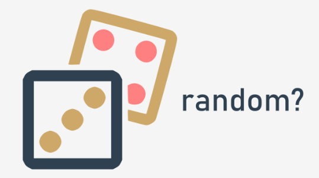

salah satu module lain yang sering digunakan adalah module `random`, dimana module ini dapat memberikan mekanisme yang menghasilkan **pseudorandom numbers**.

**pseudo -** : Disebut pseudo karena nilai yang diberikan hanya terlihat acak(random), tetapi sebetulnya nilai - nilai ini dihasilkan dengan beberapa penghitungan dan algoritma tertentu.

```python
from random import random

for i in range(5):
    print(random())
```

### seed

Terdapat fungsi `seed` yang digunakan untuk mengatur nilai yang dihasilkan dari module `random`. `seed` sendiri ada 2 varian :

- `seed()` → mengatur nilai seed dengan nilai dari waktu sekarang
- `seed(x)` → mengatur nilai seed dengan nilai x

```python
from random import random, seed

seed(0)

for i in range(5):
    print(random())
```

ketika kita run berkali - kali, nilai yang ditampilkan tetap sama, dikarenakan nilai seed-nya sama. coba saja program sebelumnya, pasti nilainya berubah-ubah terus tiap run-nya

### random dengan batasan

kalau kita ingin mendapatkan hasil berupa bilangan bulat dari random, kita bisa menggunakan fungsi dibawah ini:

- `randrange(end)`
- `randrange(beg, end)`
- `randrange(beg, end, step)`
- `randint(left, right)`

```python
from random import randrange, randint

print(randrange(200))         #  0 <= nilai random < 200
print(randrange(50, 100))     # 50 <= nilai random < 100
print(randrange(50, 200, 7))  # 50 <= nilai random < 200, nilai didapat dari 50 ditambah angka kelipatan dari 7
print(randint(5, 10))         #  5 <= nilai random <= 10, nilai batas atas diikutkan dalam random. dan randint tidak ada step
```

Kelemahan dari fungsi - fungsi diatas adalah ketika kita melakukan random beberapa kali, hasil yang didapatkan tidak unique

```python
from random import randint

for i in range(10):
    print(randint(1, 10), end=',')
```

Untuk mendapatkan nilai yang unique di setiap run, kita dapat menggunakan salah satu dari 2 fungsi ini:

- `choice(sequence)`
- `sample(sequence, elements_to_choose=1)`

```python
from random import choice, sample

siswa = ['Ani','Budi','Cakra','Desi','Edo']
print(choice(siswa))
print(sample(siswa, 2))
print(sample(siswa, 5))

lst = [1, 2, 3, 4, 5, 6, 7, 8, 9, 10]
print(choice(lst))
print(sample(lst, 5))
print(sample(lst,1))   # sama saja dengan choice, yakni mengambil 1 nilai, tetapi tipe data outputnya berbeda
```

## Module `Platform`

Terkadang kita butuh beberapa informasi yang tidak ada hubungannya dengan Python, misalkan OS yang digunakan atau hardware apa yang tertancap.

Bisa dibayangkan lingkungan (`environment`) kita membuat program seperti suatu piramdid

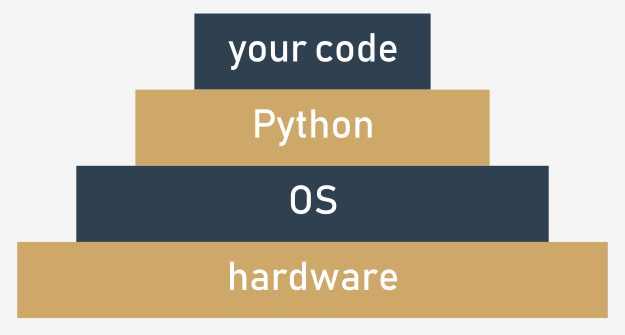

`platform(aliased,terse`)

- `aliased` → Ketika diset True (atau nilai selain 0), mungkin memberikan hasil alternatif dibandingkan dengan yang ada
- `terse` → Ketika diset True (atau nilai selain 0), mungkin memberikan hasil yang lebih pendek

```python
from platform import platform

print(platform())
print(platform(1))
print(platform(1,1))
```

```python
from platform import machine

print(machine())
```

```python
from platform import processor

print(processor())
```

```python
from platform import python_version, python_implementation, python_version_tuple

print(python_version())

print(python_implementation())
for atr in python_version_tuple():
    print(atr)
```

Daftar lengkap module yang sudah ada di python dapat dilihat disini : https://docs.python.org/3/py-modindex.html.

# Module dan Package

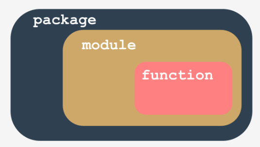

- **module itu seperti tempat kumpulan functions** - dimana kita bisa bisa menaruh sebanyak apapun function dalam satu module dan membagikannya ke semua orang;
- tentu saja, **lebih baik untuk tidak mencampur functions yang penggunaannya berbeda pada satu module yang sama**
- membuat beberapa module dapat agak sulit - cepat atau lambat diperlukan **kumpulan module** yang berfungsi untuk mengelompokkan module - module tadi
- **package**; di kumpulan module, package berguna layaknya folder/directory di kumpulan file

# Python Package Installer (PIP)

Python adalah suatu software open-source, dimana programmer bebas menggunakan dan bahkan memodifikasi kode orang lain untuk kebutuhan pribadinya, apalagi jika hasilnya dapat dibagikan dan dimanfaatkan oleh programmer lain. Python sendiri mengajak semua penggunanya untuk menjaga ekosistem python untuk tetap terbuka, nyaman, dan bebas. Agar hal ini tetap berjalan dan dapat berkembang, diperlukan tools untuk menerbitkan, menjaga, dan mengatur kode mereka.

Untuk menjaga ekosistem tadi tetap berjalan, terdapat 2 hal yang sudah ada dan tetap berjalan :

- 1. suatu gudang (repository / repo) perkumpulan berbagai package yang tersentralisasi
- 1. tools untuk pengguna mengakses repository tadi.

**Repository** (atau biasa disingkat repo) yang kita sebut bernama **PyPI (Python Package Index)** yang diatur oleh Tim **Packaging Working Group (PWG)** bagian dari Python Software Foundation.

Website dari PyPI sendiri : https://pypi.org/.

[figure not shown]

PyPI sendiri bukan satu-satunya repo python, kita-pun bisa membuat repo kita sendiri

Untuk mengakses PyPI, kita membutuhkan suatu tools khusus untuk mengaksesnya, yakni **pip**. pip sendiri merupakan kepanjangan dari 'pip installs packages', yang kalau dilanjutkan pip sendiri tidak akan habis.. ini sendiri adalah cara pengingat kita syntax menggunakan pip.

## Cara Menginstall pip

untuk yang menggunakan idle python yang diunduh dari https://www.python.org/downloads/, pip sudah otomatis terinstall

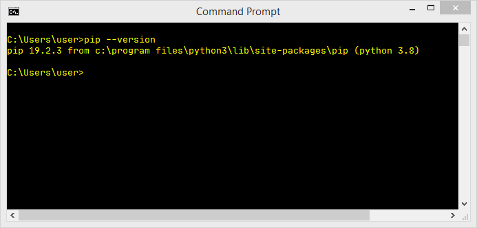

kalau tidak muncul apa-apa, kalian harus sesuaikan dulu folder dimana kalian meng-install python, contohnya : `C:\Users\USER\AppData\Local\Programs\Python\Python39\Scripts`

untuk pengguna anaconda, silahkan buka prompt dari anaconda

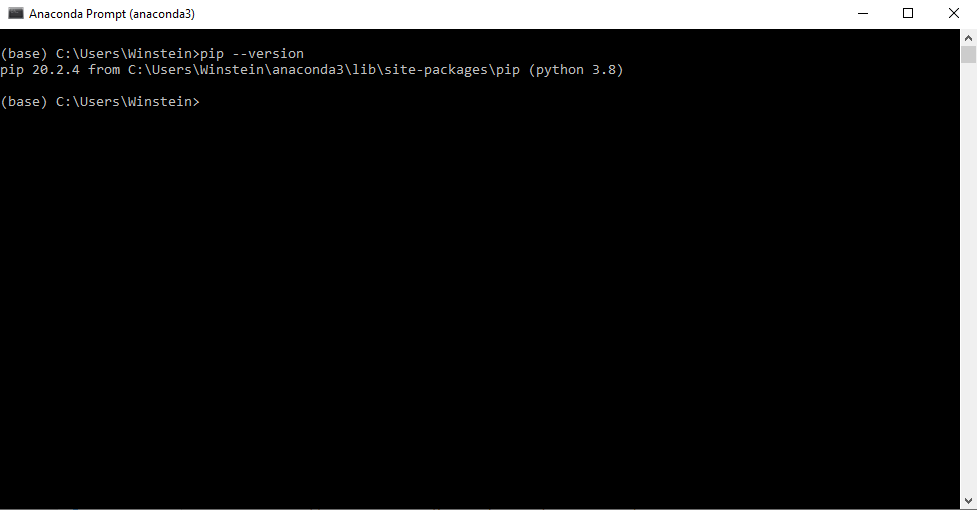

Kalau misalkan masih tidak bisa, kita bisa download pip secara manual dari website https://bootstrap.pypa.io/get-pip.py

## Cara Menggunakan pip

tidak tahu cara menggunakan pip? langsung tanya dengan pip itu sendiri dengan command `pip help`

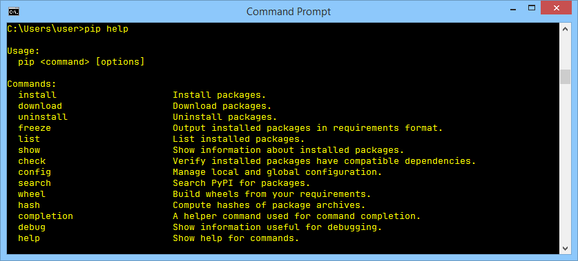

Berikut ini adalah beberapa hal yang bisa kita coba di pip:

- `pip --version` → melihat versi dari pip
- `pip list` → melihat semua package yang sudah terinstall
- `pip help` → melihat bantuan
- `pip help install` → melihat bantuan (help) untuk command install
- `pip install package_name` → meng-install package bernama package_name
- `pip install pygame` → meng-install package bernama pygame
- `pip install -U package_name` → meng-install package bernama package_name dengan versi terbaru
- `pip install -U pygame` → meng-install package bernama pygame dengan versi terbaru
- `pip install package_name==package_version` → meng-install package bernama package_name dengan versi package_version
- `pip install pygame==1.9.2` → meng-install package bernama package_name dengan versi 1.9.2
- `pip show package_name` → melihat detail dari package package_name
- `pip show pygame` → melihat detail dari package pygame
- `pip uninstall package_name` → meng-uninstall package bernama package_name
- `pip uninstall pygame` → meng-uninstall package bernama pygame

# TERIMA KASIH

# Challenge

Dodo bekerja pada sebuah perusahaan penyedia layanan internet. Perusahaan tersebut memberi kuota data 15 gigabytes (GB) dengan biaya 100k per bulan. JIka melebihi batas kuota 15 GB, maka akan dikenakan biaya 0.1k per MB (atau 100k per GB, karena 1000 MB sama dengan 1 GB).

Tuliskan semua kode python dalam bentuk fungsi `get_biaya_internet` yang menerima input:

```
`gb` = total GB yang digunakan kostumer dalam satu bulan
```

Output yang dihasilkan adalah total biaya tagihan kostumer.

Misal,

Kostumer yang menghabiskan kuoata internet sebesar 10 GB akan ditagih sebesar 100k, karena kuota yang digunakan masih di bawah 15 GB. Dengan kata lain, `get_biaya_internet(10)` menghasilkan output `100`.

Kostumer yang menghabiskan kuota sebesar 15.1 GB (15 GB + 100 MB) dalam sebulan maka harus membayar 100k ditambah 0.1k * 100 = 10k, atau sama dengan 110k. Dengan kata lain, `get_biaya_internet(15.1)` menghasilkan output `110`.

Output dalam bentuk integere (bilangan bulat) atau float (bilangan real).

```python
# TUGAS: Edit fungsi berikut sehingga menghasilkan output yang sesuai permasalahan di atas.

def get_biaya_internet(gb):
    tagihan = 100
    return tagihan
```